# Macroeconomics Q4

Kenji Sato  
2016-12-21

### Recap

The master equation:

\[ \dot k = s f(k) - (\delta + g + n) k \]

Important variables in the steady state \( k^* \):

\[ \frac{K}{L} = A k^* \]

\[ \frac{Y}{L} = Af(k^*) \]

both grow at the rate of \( g \).

### Balanced Growth

Let \( k = k^* \).

The common growth rate for

\[ K/L,\quad Y/L,\quad C/L \] is \[ g = \dot A / A. \]

The common growth rate for \[ K,\quad Y,\quad C \] is \[ g + n = \dot A/A + \dot L/L. \]

The situation in which important variables share growth rate is called **balanced growth**.

When \( k=k^* \), the economy is on the **balanced growth path**.

### Comparative Statics/Dynamics

Comparative Statics/Dynamics is a common excercise of macroeconomics.

It is important to understand what happens after a (small) parameter change.

**What happens after an increase of the saving rate?**

- \( s \) is an important policy variable for the government.
  - government's consumption-investment decision,
  - decision of tax/debt finance, or
  - changing tax treatments of saving and investment

  may have impact on \( s \).

### Preparation

```r
library(ggplot2)
library(ggthemes)

s0 = 0.3
s1 = 0.4

alpha = 0.3
delta = 0.05
g = 0.02
n = 0.01

f = function(k) {
  return(k^alpha)
}

k = seq(0.0, 25.0, by=0.01)
df = data.frame(k=k, f=f(k), s0f=s0*f(k), s1f=s1*f(k))

head(df)
```

```
     k         f        s0f       s1f
1 0.00 0.0000000 0.00000000 0.0000000
2 0.01 0.2511886 0.07535659 0.1004755
3 0.02 0.3092495 0.09277485 0.1236998
4 0.03 0.3492500 0.10477499 0.1397000
5 0.04 0.3807308 0.11421924 0.1522923
6 0.05 0.4070905 0.12212716 0.1628362
```

### Comparative Statics/Dynamics

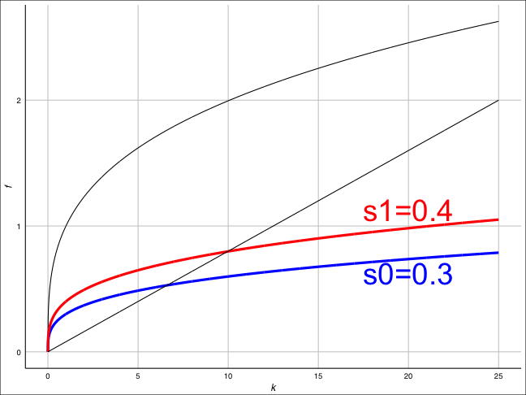

```r
fig = ggplot(df) +
  geom_line(aes(x=k, y=f)) + # Production Function
  geom_line(aes(x=k, y=s0f), color='blue', size=1.5) + # For s0
  geom_line(aes(x=k, y=s1f), color='red', size=1.5) +  # For s1
  geom_line(aes(x=k, y=(delta+g+n)*k))  # Break-Even
```

### Comparative Statics

- \( k^* \) is larger when \( s \) gets larger.
  - **Policy that increases the saving rate increases GDP per capita**: \[ \frac{Y}{L} = A f(k^*) \]
  - There is a **level effect**
- What about growth rate?
  - In the long run, there is no change: fixed at \( g \).There is **no growth effect**.
  - In the shorter run, there is some change.

### Comparative Dynamics

- Suppose that the economy is on the balanced growth path.
  - i.e., \( k = k^* \)
- At time \( t_0 \), the economy experiences a sudden increase in \( s \) (from s0 to s1).
  - \( k \) gradually moves toward the new \( k^* \) **because the new saving level is greater than the break-even level of investment**.
  - Investment per capita immediately **jumps** up to a point on the new (red) saving curve. (**jump variable**)
  - Consumption per capita immediately falls because of the rise of investment. (**jump variable**)

### Simulation for k

```r
k0 = (s0 / (g + n + delta))^(1 / (1 - alpha)) # steady state
t0 = 10  # Change of policy

solow_update = function(t, k){
  if (t < t0){
    return(k + dt * (s0 * f(k) - (delta + g + n) * k))
  } else {
    return(k + dt * (s1 * f(k) - (delta + g + n) * k))
  }
}

dt = 0.01   # controls precision of approximation
t_max = 100   # simulation for t_max years
t = seq(from=0, to=t_max, by=dt)
simulation = as.data.frame(t)

simulation[1, "k"] = k0
for (i in 2:nrow(simulation)){
  simulation[i, "k"] = solow_update(simulation[i-1, "t"],
                                    simulation[i-1, "k"])
}
```

### Simulation for k

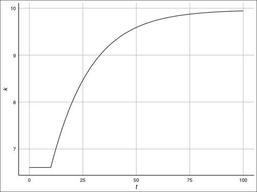

```r
ggplot(simulation, aes(x=t, y=k)) + geom_line() + theme_gdocs()
```

At \( t = t_0 \), \( k \) starts to increase and

it stops increasing when it attains the new steady state value.

### Simulation for K/L (log scale for y-axis)

Let \( A(0) = 1 \). Plot using a logarithmic scale for y-Axis.

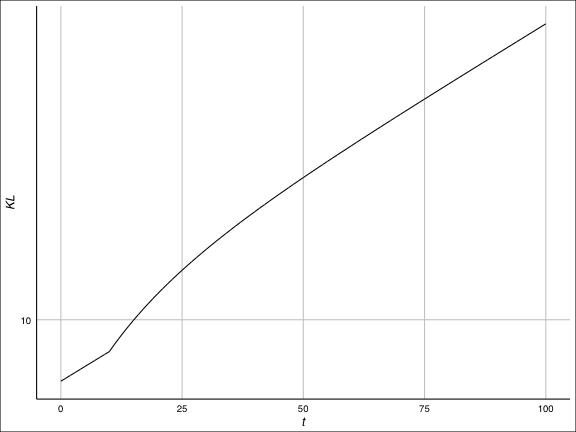

```r
simulation$KL = simulation$k * exp(g*simulation$t)
ggplot(simulation, aes(x=t, y=KL)) + geom_line() + scale_y_log10() + theme_gdocs()
```

### Simulation for C/L (log scale for y-axis)

Exercise: Reproduce the following graph.

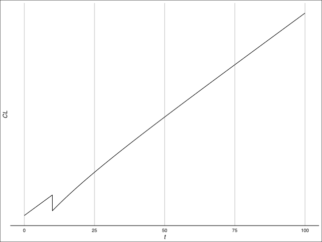

### Transition Dynamics

Note that the growth rate, \( g_{K/L} \) of \( K/L \) satisfies

\[ g_{K/L}(t) = g + g_k(t), \]

where \( g \) is the exogenous growth rate of \( A \), \( g_k \) is the growth rate of \( k \).

After an increase in saving rate, we get \( \dot k > 0 \) and thereby \( g_k(t) > 0 \).

**On the transition path, the growth of per capita capital is faster than on the BGP**.

It seems to be consistent with observations about NICs.

### Golden rule

- There is a certain value for \( s \) that maximizes steady state consumption.
  - Such saving rate is called **Golden rule saving rate** and denoted by \( s_G \).
  - For Cobb–Douglas production funtion \( f(k) = k^\alpha \), \( s_G = \alpha \). (Why?)

### Golden rule (cont'd)

Note that

\[ \begin{aligned} c^* &= (1 - s) f(k^*) \\ &= f(k^*) - (\delta + g + n) k^* \end{aligned} \]

When \( c^* \) is maximized, we should have (think of \( c^* \) as a function of \( k^* \))

\[ f'(k^*) = \delta + g + n \]

Let \( k^*_G \) be the unique stock level that satisfies the above equation. **Golden rule capital stock**.

### Simulation for C/AL

Exercise: Reproduce the following graph.

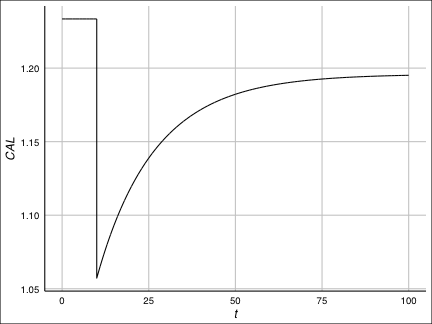

Observe that the new steady state value, \( c^* \), for \( c = C/(AL) \) is smaller after the parameter change considered above.

### Steady state consumption

- If \( s_0 < s_1 \le s_G \), the parameter shift from \( s_0 \) to \( s_1 \) necessarily makes \( (C/AL)^* \) larger after the shift.
  - Confirm this fact with pen and paper, and with R.
- If \( s_G \le s_0 < s_1 \), \( (C/AL)^* \) gets smaller.
  - This is what we have observed.

### Dynamic Inefficiency

- Saving rate greater than the golden-rule level is unrealistic.
  - If you lower the saving rate, you can increase consumption immediately and forever.
  - There is **dynamic inefficiency**.

### Growth Accounting

\( Y = F(K, AL) \) implies that

\[ \begin{aligned} \dot Y &= \frac{\partial Y}{\partial K} \dot K + \frac{\partial Y}{\partial (AL)} \frac{d}{dt}(AL)\\ &= \frac{\partial Y}{\partial K} \dot K + \left[\frac{\partial Y}{\partial (AL)} A\right] \dot L + \left[\frac{\partial Y}{\partial (AL)} L\right] \dot A\\ &=: \frac{\partial Y}{\partial K} \dot K + \frac{\partial Y}{\partial L} \dot L + \left[\frac{\partial Y}{\partial (AL)} L\right] \dot A. \end{aligned} \]

We therefore have

\[ \frac{\dot Y}{Y} = \frac{\partial Y}{\partial K} \frac{K}{Y} \frac{\dot K}{K} + \frac{\partial Y}{\partial L} \frac{L}{Y} \frac{\dot L}{L} + \left[\frac{\partial Y}{\partial (AL)} \frac{AL}{Y} \right] g. \]

### Growth Accounting (cont'd)

Define

\[ \begin{aligned} \alpha_K (t) &:= \frac{K}{Y} \frac{\partial Y}{\partial K} & (\text{capital elasticity of output}) \\ \alpha_L (t) &:= \frac{L}{Y} \frac{\partial Y}{\partial L} & (\text{labor elasticity of output}) \end{aligned} \]

**Veryfy for the Cobb–Douglas family that they are constant: \( \alpha_K = \alpha \) and \( \alpha_L = 1-\alpha \)**.

By Euler's theorem on CRS functions,

\[ \alpha_K (t) + \alpha_L (t) = 1 \]

### Growth Accounting (cont'd)

1% increase in capital input results in \( \alpha_K \)% increase in output.

\[ \alpha_K = \frac{K}{Y} \frac{\partial Y}{\partial K} \simeq \dfrac{ \dfrac{Y + \Delta Y}{Y} }{ \dfrac{K + \Delta K}{K} } \]

### Growth Accounting (cont'd)

By employing this notation, the decomposition of \( \dot Y/Y \) becomes

\[ \frac{\dot Y}{Y} = \alpha_K \frac{\dot K}{K} + \alpha_L \frac{\dot L}{L} + R, \]

where

\[ R := \left[\frac{\partial Y}{\partial (AL)} \frac{AL}{Y} \right] g = \alpha_L g, \]

called the **Solow residual**.

**All terms other than \( R \) can be obtained from data.**

### Growth Accounting (cont'd)

Equivalently,

\[ g_{Y/L} = \alpha_K g_{K/L} + R = \alpha_K g_{K/L} + a_L g. \]

In the steady state, \( \alpha_K \) fraction of growth in output per worker is attributable to capital accumulation. The rest is due to the technological progress.

After extended to incorporate **human capital accumulation**, the Solow model fits fairly well with data. See Mankiw, Romer and Weil (1992, QJE).